# Praca Domowa 1

Indywidualnie, zaimplementować model sieci neuronowej (MLP) do klasyfikacji w `torch` i przetestować go na dwóch zbiorach danych: XOR (wygenerować), oraz iris (pobrać). Powstały raport w formatach `.ipynb` oraz `.html` powinien zawierać wnioski z przeprowadzonej analizy.

1. do 2 punktów uzyskuje się za skuteczność klasyfikacji modeli i wizualizację procesu uczenia,
2. do 2 punktów uzyskuje się za analizę porównawczą różnych architektur sieci neuronowych (liczby neuronów i warstw),
3. 1 punkt uzyskuje się za analizę porównawczą różnych wartości `learning_rate`,
4. 1 punkt uzyskuje się za wytrenowanie skutecznego modelu na zbiorze danych MNIST i analizę macierzy pomyłek tej klasyfikacji,
5. 1 punkt uzyskuje się za ewaluowanie powyższych zjawisk na podzbiorze treningowym i testowym (analizę zjawiska przeuczenia),
6. 1 punkt uzyskuje się za animację zmiany granic decyzyjnych klasyfikacji podczas uczenia (na wybranym zbiorze danych),
7. do 2 punktów uzyskuje sie za jakość raportu (opisu, wizualizacji, kodu).

**Uwaga!** Warto zacząć od uczenia bardzo małych sieci i stopniowo zwiększać ich skomplikowanie.

Deadline: 16 marca 23:59. Na zajęciach 17 marca 5 wybranch osób krótko zaprezentuje swoje wyniki.

Pracę zgłaszamy poprzez PR o tytule `[PD1] Imię Nazwisko` do folderu `homeworks/pd1/imię_nazwisko`.

### Create XOR dataset

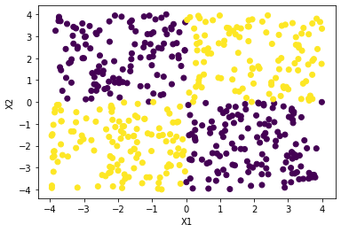

```python
import numpy as np
import matplotlib.pyplot as plt

xor_x = np.random.uniform(low=-4, high=4, size=(500,2))
xor_y = (np.bitwise_xor(np.sign(xor_x[:,0]).astype(int),np.sign(xor_x[:,1]).astype(int))/2+1).astype(int)
plt.scatter(xor_x[:,0],xor_x[:,1],c=xor_y)
plt.xlabel('X1')
plt.ylabel('X2')

plt.show()
```

### Get iris dataset

```python
import numpy as np
import pandas as pd
from sklearn.datasets import load_iris
iris = load_iris()
df_iris = pd.DataFrame(data= np.c_[iris['data'], iris['target']],
                     columns= iris['feature_names'] + ['target'])
```

```python
df_iris.head()
```

|  | sepal length (cm) | sepal width (cm) | petal length (cm) | petal width (cm) | target |
| --- | --- | --- | --- | --- | --- |
| 0 | 5.1 | 3.5 | 1.4 | 0.2 | 0.0 |
| 1 | 4.9 | 3.0 | 1.4 | 0.2 | 0.0 |
| 2 | 4.7 | 3.2 | 1.3 | 0.2 | 0.0 |
| 3 | 4.6 | 3.1 | 1.5 | 0.2 | 0.0 |
| 4 | 5.0 | 3.6 | 1.4 | 0.2 | 0.0 |

### Get MNIST

```python
import torch
from torch import nn
from torch.utils.data import DataLoader
from torchvision import datasets
from torchvision.transforms import ToTensor

# Download training data from open datasets.
MNIST_training_data = datasets.MNIST(
    root="data",
    train=True,
    download=True,
    transform=ToTensor()
)

# Download test data from open datasets.
MNIST_test_data = datasets.MNIST(
    root="data",
    train=False,
    download=True,
    transform=ToTensor()
)
```

## Creating models - XOR

##### Preparing dataloaders

```python
import torch
import numpy as np
from torch.utils.data import DataLoader

df_xor = pd.DataFrame(np.hstack((xor_x,xor_y[:,None])))
df_xor.iloc[:,2] = df_xor.iloc[:,2].astype('int')
df_xor = df_xor.sample(frac=1).reset_index(drop=True)

split_train = round(0.8*xor_x.shape[0])
df_train, df_test = df_xor.iloc[:split_train,:], df_xor.iloc[split_train:,:]


dataloader_train = DataLoader(np.array(df_train), batch_size=1,num_workers=3)
dataloader_test = DataLoader(np.array(df_test), batch_size=1,num_workers=3)
```

##### Helper function for model testing

```python
import matplotlib.pyplot as plt

def train_xor(model, epochs, learning_rate):
    xor_network = model

    loss = torch.nn.CrossEntropyLoss(reduction='none')
    optimizer = torch.optim.SGD(xor_network.parameters(), lr=learning_rate)

    losses = []
    errors_train = []
    errors_test = []

    for epoch in range(epochs):
        losses_iter = []
        errors_train_iter = []
        errors_test_iter = []

        for data in dataloader_test:
            X, y = data[:,0:2],data[:,2].long()
            y_hat = xor_network(X.float())
            errors_test_iter += [(y != y_hat.argmax(1)).float().mean().item()]

        for data in dataloader_train:
            X, y = data[:,0:2],data[:,2].long()
            y_hat = xor_network(X.float())
            errors_train_iter += [(y != y_hat.argmax(1)).float().mean().item()]

        for data in dataloader_train:
            X, y = data[:,0:2],data[:,2].long()
            y_hat = xor_network(X.float())
            l = loss(y_hat, y)
            optimizer.zero_grad()
            l.mean().backward()
            losses_iter += [l.mean().item()]
            optimizer.step()

        errors_train += [np.mean(errors_train_iter)]
        errors_test += [np.mean(errors_test_iter)]
        losses += [np.mean(losses_iter)]

    plt.figure(figsize=(6, 4))
    plt.plot(range(epochs), losses)
    plt.title("Loss")
    plt.legend(['Loss'])
    plt.show()

    plt.figure(figsize=(6, 4))
    plt.plot(range(epochs), errors_train)
    plt.plot(range(epochs), errors_test)
    plt.title(f'Learning curves || MSE train: {round(errors_train[-1],2)} || MSE test: {round(errors_test[-1],2)}')
    plt.legend(['Error_train', 'Error_test'])
    plt.show()

    xor_y_plot = xor_network(torch.Tensor(np.array(df_test.iloc[:,:2])).float())
    plt.scatter(df_test.iloc[:,0],df_test.iloc[:,1],c=[round(l.argmax(0).item()) for l in xor_y_plot])
    plt.xlabel('x1')
    plt.ylabel('x2')
    plt.title('XOR classifiction - results')
    plt.show()
```

#### Model testing

Model 1 - A simple MLP

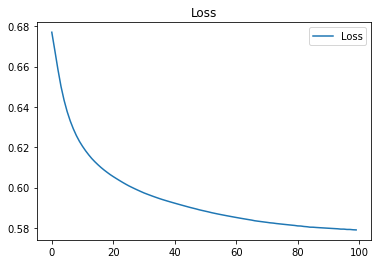

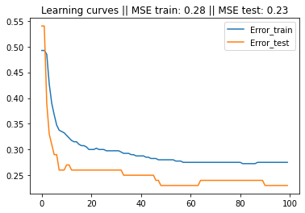

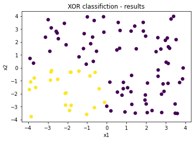

```python
xor_network = torch.nn.Sequential(
    torch.nn.Linear(2, 4),
    torch.nn.ReLU(),
    torch.nn.Linear(4, 2),
    torch.nn.ReLU(),
    torch.nn.Linear(2, 2),
    torch.nn.Softmax(dim=1)
)

epochs = 100
learning_rate = 0.003

train_xor(xor_network, epochs, learning_rate)
```

Model 2 - A large MLP

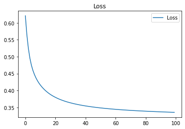

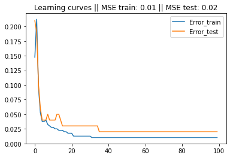

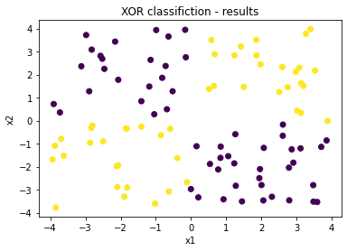

```python
xor_network = torch.nn.Sequential(
    torch.nn.Linear(2, 40),
    torch.nn.ReLU(),
    torch.nn.Linear(40, 2),
    torch.nn.ReLU(),
    torch.nn.Linear(2, 2),
    torch.nn.Softmax(dim=1)
)

epochs = 100
learning_rate = 0.003

train_xor(xor_network, epochs, learning_rate)
```

Model 3 - A simple MLP with large learning rate

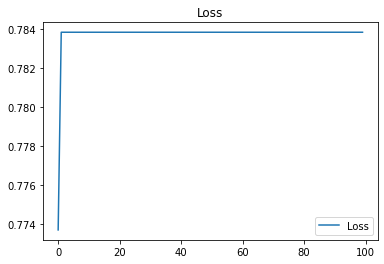

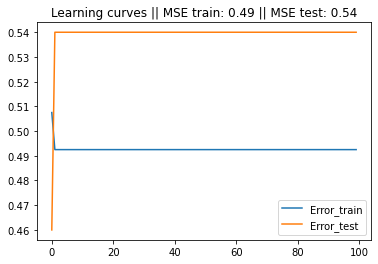

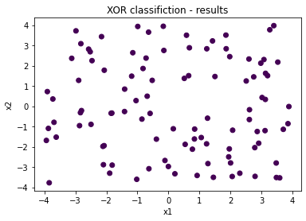

```python
xor_network = torch.nn.Sequential(
    torch.nn.Linear(2, 4),
    torch.nn.ReLU(),
    torch.nn.Linear(4, 2),
    torch.nn.ReLU(),
    torch.nn.Linear(2, 2),
    torch.nn.Softmax(dim=1)
)

epochs = 100
learning_rate = 3

train_xor(xor_network, epochs, learning_rate)
```

Model 4 - A simple MLP with too few layers

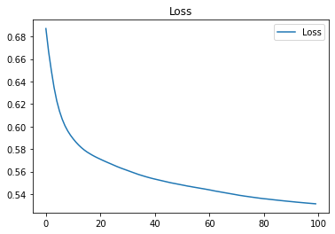

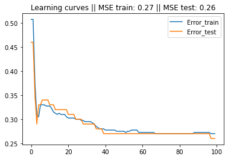

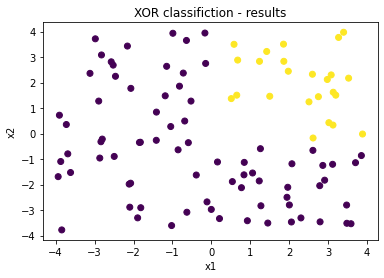

```python
xor_network = torch.nn.Sequential(
    torch.nn.Linear(2, 2),
    torch.nn.ReLU(),
    torch.nn.Linear(2, 2),
    torch.nn.Softmax(dim=1)
)

epochs = 100
learning_rate = 0.003

train_xor(xor_network, epochs, learning_rate)
```

### XOR Models summary

Learning rate:

- when learning rate is too high, the model will not converge (model 3)
- when learning rate is too low, the model will converge very slowly

## Creating models - Iris

##### Preparing dataloaders

```python
df_iris.head(2)
```

[output not shown]

```python
df_iris.iloc[:,4] = df_iris.iloc[:,4].astype('int')
df_iris = df_iris.sample(frac=1).reset_index(drop=True)

split_train = round(0.6*df_iris.shape[0])
df_train, df_test = df_iris.iloc[:split_train,:], df_iris.iloc[split_train:,:]

dataloader_train = DataLoader(np.array(df_train), batch_size=1,num_workers=3)
dataloader_test = DataLoader(np.array(df_test), batch_size=1,num_workers=3)
```

##### Helper function for model testing

```python
import matplotlib.pyplot as plt

def train_iris(model, epochs, learning_rate):
    iris_network = model

    loss = torch.nn.CrossEntropyLoss(reduction='none')
    optimizer = torch.optim.SGD(iris_network.parameters(), lr=learning_rate)

    losses = []
    errors_train = []
    errors_test = []

    for epoch in range(epochs):
        losses_iter = []
        errors_train_iter = []
        errors_test_iter = []

        for data in dataloader_test:
            X, y = data[:,0:4],data[:,4].long()
            y_hat = iris_network(X.float())
            errors_test_iter += [(y != y_hat.argmax(1)).float().mean().item()]

        for data in dataloader_train:
            X, y = data[:,0:4],data[:,4].long()
            y_hat = iris_network(X.float())
            errors_train_iter += [(y != y_hat.argmax(1)).float().mean().item()]

        for data in dataloader_train:
            X, y = data[:,0:4],data[:,4].long()
            y_hat = iris_network(X.float())
            l = loss(y_hat, y)
            optimizer.zero_grad()
            l.mean().backward()
            losses_iter += [l.mean().item()]
            optimizer.step()

        errors_train += [np.mean(errors_train_iter)]
        errors_test += [np.mean(errors_test_iter)]
        losses += [np.mean(losses_iter)]

    plt.figure(figsize=(6, 4))
    plt.plot(range(epochs), losses)
    plt.title("Loss")
    plt.legend(['Loss'])
    plt.show()

    plt.figure(figsize=(6, 4))
    plt.plot(range(epochs), errors_train)
    plt.plot(range(epochs), errors_test)
    plt.title(f'Learning curves || MSE train: {round(errors_train[-1],2)} || MSE test: {round(errors_test[-1],2)}')
    plt.legend(['Error_train', 'Error_test'])
    plt.show()

    iris_y_plot = iris_network(torch.Tensor(np.array(df_test.iloc[:,:4])).float())
    plt.scatter(df_test.iloc[:,1],df_test.iloc[:,3],c=[round(l.argmax(0).item()) for l in iris_y_plot])
    plt.xlabel('x1')
    plt.ylabel('x2')
    plt.title('XOR classifiction - results')
    plt.show()
```

#### What to expect

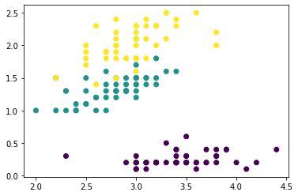

```python
plt.scatter(df_iris.iloc[:,1],df_iris.iloc[:,3],c=df_iris.iloc[:,4]);
```

##### Model testing

Model 1 - A simple MLP

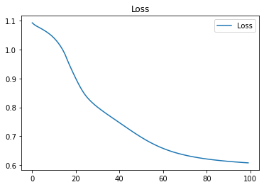

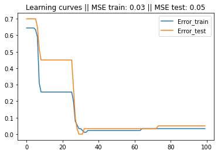

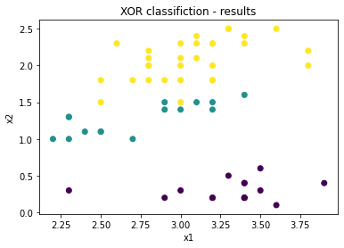

```python
iris_network = torch.nn.Sequential(
    torch.nn.Linear(4, 30),
    torch.nn.ReLU(),
    torch.nn.Linear(30, 15),
    torch.nn.ReLU(),
    torch.nn.Linear(15, 3),
    torch.nn.Softmax(dim=1)
)

epochs = 100
learning_rate = 0.003

train_iris(iris_network, epochs, learning_rate)
```

Model 2 - A simple MLP with larger learning rate

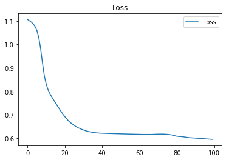

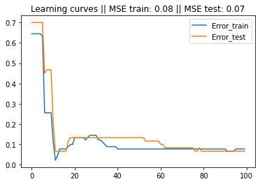

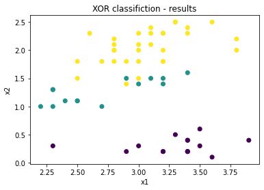

```python
iris_network = torch.nn.Sequential(
    torch.nn.Linear(4, 30),
    torch.nn.ReLU(),
    torch.nn.Linear(30, 15),
    torch.nn.ReLU(),
    torch.nn.Linear(15, 3),
    torch.nn.Softmax(dim=1)
)

epochs = 100
learning_rate = 0.01

train_iris(iris_network, epochs, learning_rate)
```

Model 2 - A simple MLP with large learning rate

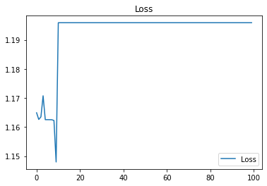

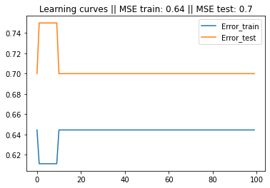

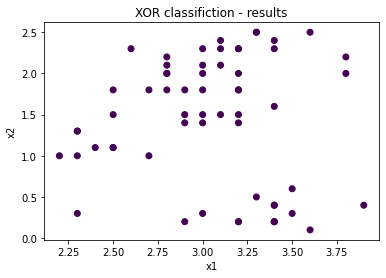

```python
iris_network = torch.nn.Sequential(
    torch.nn.Linear(4, 30),
    torch.nn.ReLU(),
    torch.nn.Linear(30, 15),
    torch.nn.ReLU(),
    torch.nn.Linear(15, 3),
    torch.nn.Softmax(dim=1)
)

epochs = 100
learning_rate = 1

train_iris(iris_network, epochs, learning_rate)
```

Model 3 - A simple MLP with too few layers

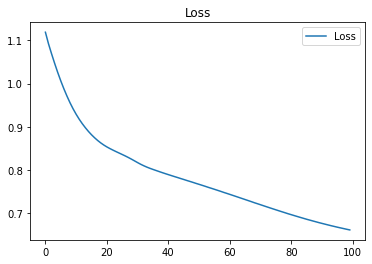

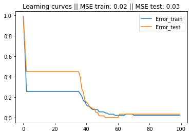

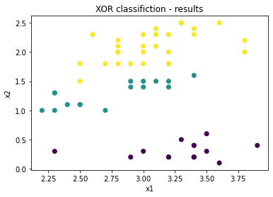

```python
iris_network = torch.nn.Sequential(
    torch.nn.Linear(4, 15),
    torch.nn.ReLU(),
    torch.nn.Linear(15, 3),
    torch.nn.Softmax(dim=1)
)

epochs = 100
learning_rate = 0.003

train_iris(iris_network, epochs, learning_rate)
```

Model 4 - A simple MLP with too few neurons

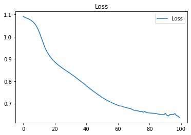

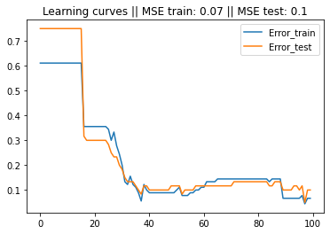

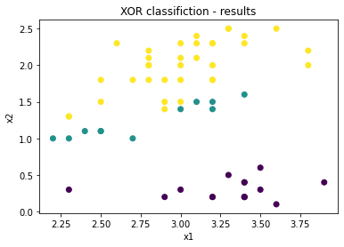

```python
iris_network = torch.nn.Sequential(
    torch.nn.Linear(4, 4),
    torch.nn.ReLU(),
    torch.nn.Linear(4, 4),
    torch.nn.ReLU(),
    torch.nn.Linear(4, 3),
    torch.nn.Softmax(dim=1)
)

epochs = 100
learning_rate = 0.01

train_iris(iris_network, epochs, learning_rate)
```

Model 5 - A complex MLP with too many neurons and layers

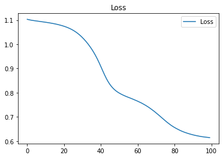

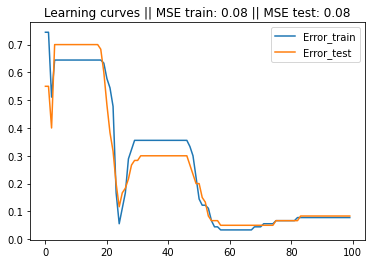

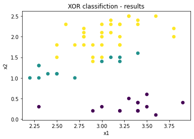

```python
iris_network = torch.nn.Sequential(
    torch.nn.Linear(4, 60),
    torch.nn.ReLU(),
    torch.nn.Linear(60, 40),
    torch.nn.ReLU(),
    torch.nn.Linear(40, 30),
    torch.nn.ReLU(),
    torch.nn.Linear(30, 10),
    torch.nn.ReLU(),
    torch.nn.Linear(10, 3),
    torch.nn.Softmax(dim=1)
)

epochs = 100
learning_rate = 0.003

train_iris(iris_network, epochs, learning_rate)
```

### Iris Models summary

Learning rate:

- when learning rate is too high, the model will not converge (model 2)

## Creating models - MNIST

##### Preparing dataloaders

```python
dataloader_train = DataLoader(MNIST_training_data, batch_size=256, shuffle=True,num_workers=2)
dataloader_test = DataLoader(MNIST_test_data, batch_size=256, shuffle=True,num_workers=2)
```

MNIST model

```python
net = torch.nn.Sequential(
    torch.nn.Flatten(),
    torch.nn.Linear(784, 64),
    torch.nn.ReLU(),
    torch.nn.Linear(64, 32),
    torch.nn.ReLU(),
    torch.nn.Linear(32, 10)
)

learning_rate = 0.05
loss = torch.nn.CrossEntropyLoss(reduction='none')
optimizer = torch.optim.SGD(net.parameters(), lr=learning_rate)

num_iter = 10

losses = []
errors_train = []
errors_test = []

import tqdm
for epoch in tqdm.tqdm(range(num_iter)):
    losses_iter = []
    errors_train_iter = []
    errors_test_iter = []

    for X, y in dataloader_test:
        y_hat = net(X)
        errors_test_iter += [(y != y_hat.argmax(1)).float().mean().item()]

    for X, y in dataloader_train:
        y_hat = net(X)
        errors_train_iter += [(y != y_hat.argmax(1)).float().mean().item()]

    for X, y in dataloader_train:
        y_hat = net(X)
        errors_train_iter += [(y != y_hat.argmax(1)).float().mean().item()]
        l = loss(y_hat, y)
        optimizer.zero_grad()
        l.mean().backward()
        losses_iter += [l.mean().item()]
        optimizer.step()

    errors_train += [np.mean(errors_train_iter)]
    errors_test += [np.mean(errors_test_iter)]
    losses += [np.mean(losses_iter)]
```

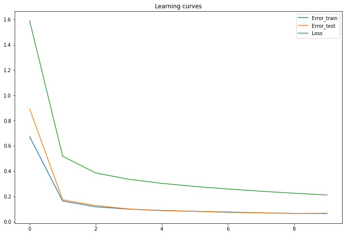

```python
import matplotlib.pyplot as plt
plt.figure(figsize=(12, 8))
plt.plot(range(num_iter), errors_train)
plt.plot(range(num_iter), errors_test)
plt.plot(range(num_iter), losses)
plt.title("Learning curves")
plt.legend(['Error_train', 'Error_test', 'Loss'])
plt.show()
```

#### Confusion Matrix

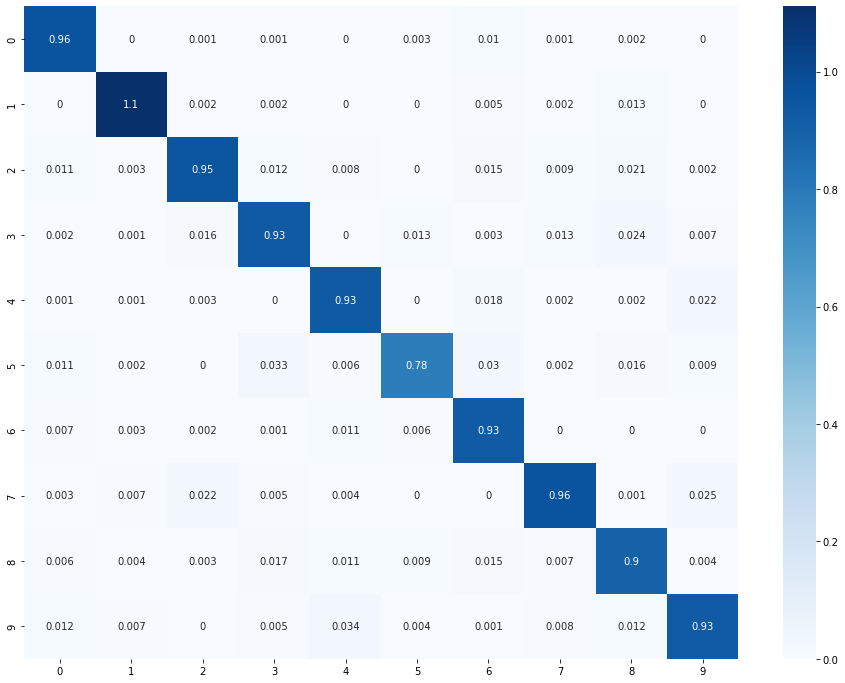

```python
from sklearn.metrics import confusion_matrix
import seaborn as sn
import pandas as pd

y_pred = []
y_true = []

for inputs, labels in dataloader_test:
        output = net(inputs)
        output = (torch.max(torch.exp(output), 1)[1]).data.cpu().numpy()
        y_pred.extend(output)
        labels = labels.data.cpu().numpy()
        y_true.extend(labels)
classes = ('0', '1', '2', '3', '4', '5', '6', '7', '8', '9')

cf_matrix = confusion_matrix(y_true, y_pred)
df_cm = pd.DataFrame(cf_matrix/np.sum(cf_matrix) *10, index = [i for i in classes],
                     columns = [i for i in classes])
plt.figure(figsize = (16, 12))
sn.heatmap(df_cm, annot=True, cmap="Blues")
plt.show()
```

### MNIST confusion matrix summary

From the confusion martix above we can see that the model is very good at classifying the digits. However, some ditigs are more difficult to classify than others.

The most common mistake is to classify digit 9 as digit 4 and digit 5 as digit 3.